# A Quick Tour Through State Space reconstruction

Short Course ‘An Introduction to Empirical Dynamics Modelling, ICTP SAIRF’, Tutorial #1

Brenno Cabella, Paulo Inácio Prado, Renato Coutinho, Marina Rillo, Rafael Lopes, Roberto Kraenkel

ICTP SAIRF São Paulo School of Mathematical Biology, January 2018

```r
library(rEDM)
```

Before you proceed, please read carefully the introduction and the first section (*“Empirical Dynamic Modelling”*) of rEDM’s tutorial that you can find [here](https://cran.r-project.org/web/packages/rEDM/vignettes/rEDM-tutorial.html) or in your local R installation with the command

```r
vignette("rEDM-tutorial", package="rEDM")
```

## A simple case: harmonic oscilator

This first part is to get the grips with R language and to figure out how to reconstruct a state space with only one time series and its lags. For the first example we use a very well known system and its representation on state space, the bidimensional harmonic oscilator:

$\dot{x}=y$

$\dot{y}=-x$

which has the solution $x(t)=\sin(t), \ y(t)=\cos(t)$ and so we can draw the state space of this system by laying down in cartesian axis its two degrees of freedom, $x(t)$ and $y(t)$. This system has a circular atractor, that is, all the possible states lie over a circle in the state space:

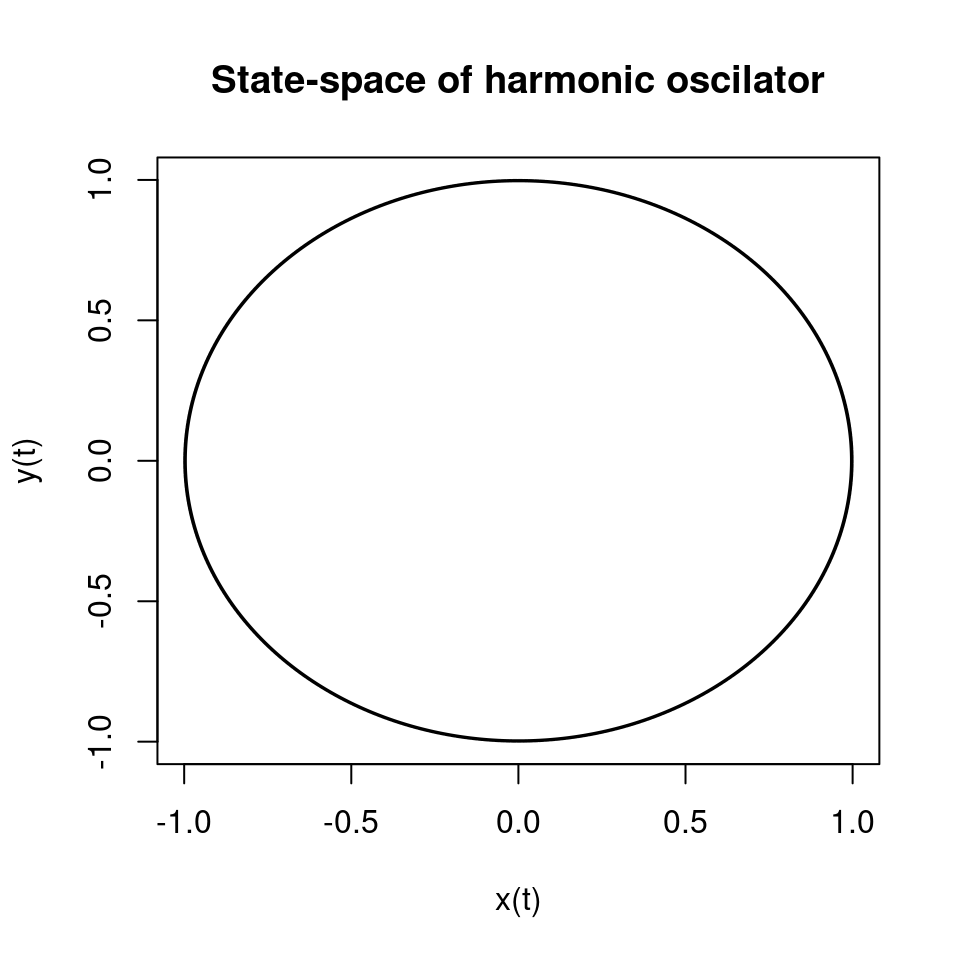

```r
## Generate the data at 0.2 time intervals
time1<-seq(0, 500, by = 0.2)
x1<-sin(time1)
y1<-cos(time1)
## Plot the state space
plot(x1, y1, type = 'l', main = "State-space of harmonic oscilator",
     cex=0.2, xlab="x(t)", ylab="y(t)")
```

And here is the time series for the two state variables:

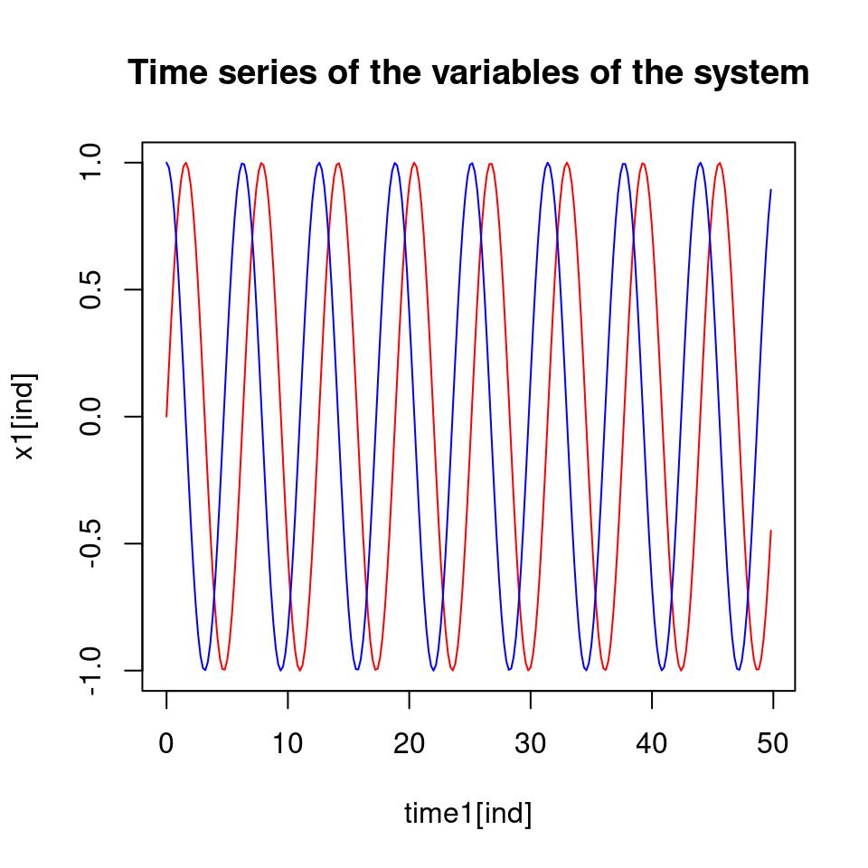

```r
## Time series of the 1st 250 observations
ind <- 1:250
plot(time1[ind], x1[ind], type = 'l',
     main = "Time series of the variables of the system",
     col = "red")
lines(time1[ind], y1[ind], col = "blue")
```

## A reconstruction of the state space

Now suppose all you information you have about this system is a time series of one of the state variables, say $x$. Because $y(t)$ is missing we are not able to construct a state space as we saw above, but by using the result of Takens theorem we can construct a **shadow manyfold** that recovers the information of the true state space. This reconstruction is not a copy of the original atractor, but it is a valid topological reconstruction of the original, a “shadow”.

To do this we generate new variables by lagging the time series by multiples of a time interval $\tau$. In this case we will use the interval between observations ($\tau=0.2$ time units). The R commands below creates a data table object ( which is called a *data frame* in R) with the original time series and its lagged version. The handy function `make_block` by the rEDM authors does this job. Use this link to download the function to your working directory and then load it with the command:

```r
load("make_block.R")
```

And now you can create a lagged variable dataframe in R by copying the following code and pasting in the R console:

```r
## Data frame with observations with tau = 0.2 with one lag
df1 <- make_block(data.frame(x=x1), t=time1, max_lag = 2)
```

A quick look at the first and last lines of the data frame can help to understand the lagged variabel structure:

```r
## Take a look in the lagged data to understand how the function works
head(df1)
```

```
##   time         x       x_1
## 1  0.0 0.0000000        NA
## 2  0.2 0.1986693 0.0000000
## 3  0.4 0.3894183 0.1986693
## 4  0.6 0.5646425 0.3894183
## 5  0.8 0.7173561 0.5646425
## 6  1.0 0.8414710 0.7173561
```

```r
tail(df1)
```

```
##       time           x         x_1
## 2496 499.0  0.49099533  0.65428133
## 2497 499.2  0.30813490  0.49099533
## 2498 499.4  0.11299011  0.30813490
## 2499 499.6 -0.08665925  0.11299011
## 2500 499.8 -0.28285377 -0.08665925
## 2501 500.0 -0.46777181 -0.28285377
```

By ploting the time series in function of their lagged versions we get the shadow manyfold, which is similar to the original one:

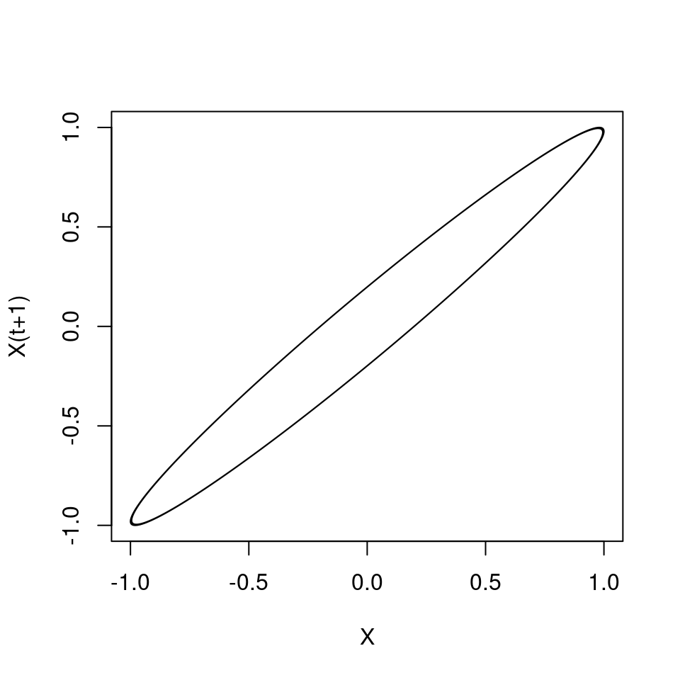

```r
plot(x_1 ~ x, data=df1, type="l",
     xlab = "X", ylab = "X(t+1)" )
```

## Noisy data

How robust is the atratctor reconstruction to random noise? There are mainly two types of noise or error in data, which we call **process errors** and **observational errors**. The first one is about random changes of the state variables, like environmental fluctuations that affect the dynamic. The second type of error appears when we are not totally able to measure the interesting data, when we miss some counts on the counting of individuals of species, or do error in the sampling or measurements. Observational errors do not affect the dynamic, only the portrait we make of it.

In this section we will check this simulating that the time series has measurement errors. Use the commands below to simulate that the time series has independent measurement errors with constant variance. To do that we add to each observation a value drawn from a Gaussian distribution with zero mean and standard deviation wich is 1/12 of the standard deviation of the time series itself.

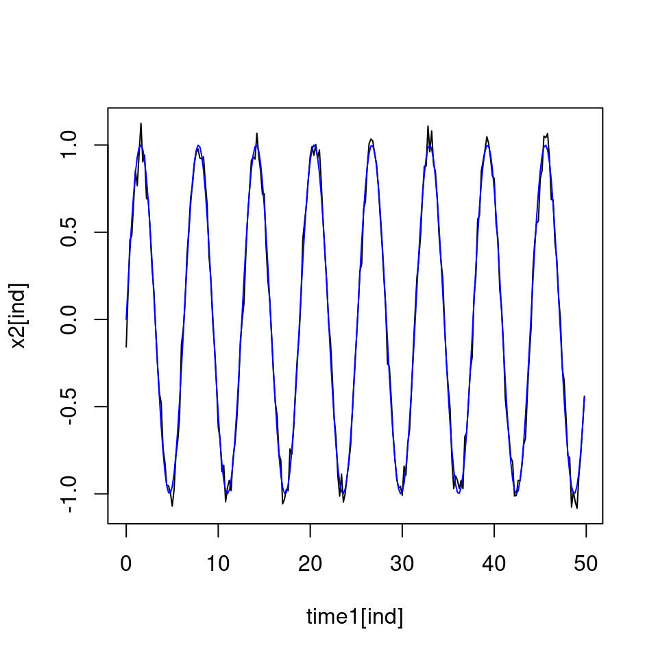

```r
## a new vector of observed values + Gaussian iid error
x2 <- x1 + rnorm(n = length(x1), mean = 0, sd = sd(x1)/12)
## Time series
plot(x2[ind] ~ time1[ind], type="l")
lines(x1[ind] ~time1[ind], type="l", col="blue")
```

We thus proceed by creating a new data frame with the lagged variables and by ploting the new shadow manyfold:

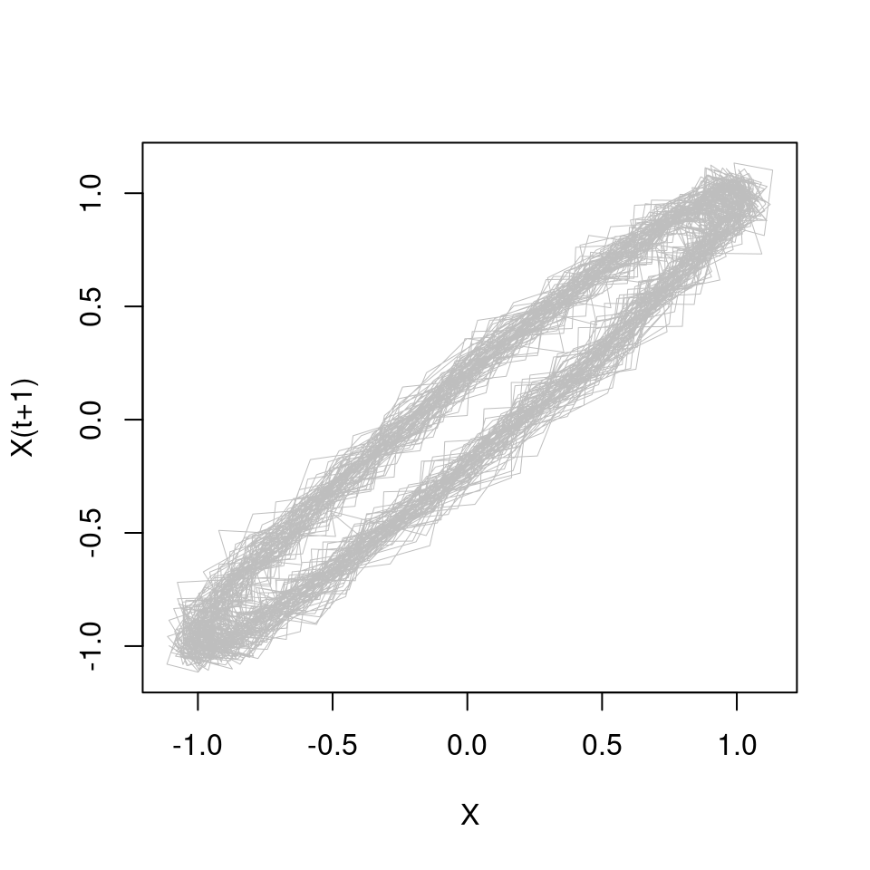

```r
## Data frame with lagged variables
df2 <- make_block( data.frame(x = x2))
## Shadow manyfold with embedding = 2
plot(x_1 ~ x, data=df2, type="l",
     ylab = "X(t+1)", xlab = "X" , col="grey",
     lwd=0.5)
```

### Increasing the noise

Measurement errors make atractors more complex by spreading points (and thus trajectories) over the state space. Of course this effect gets larger as we increase the measurement error. We now will investigate a bit more how this affects the atractor reconstruction. The commands below doubles the measurement error of the time series and plots the shadow manyfold:

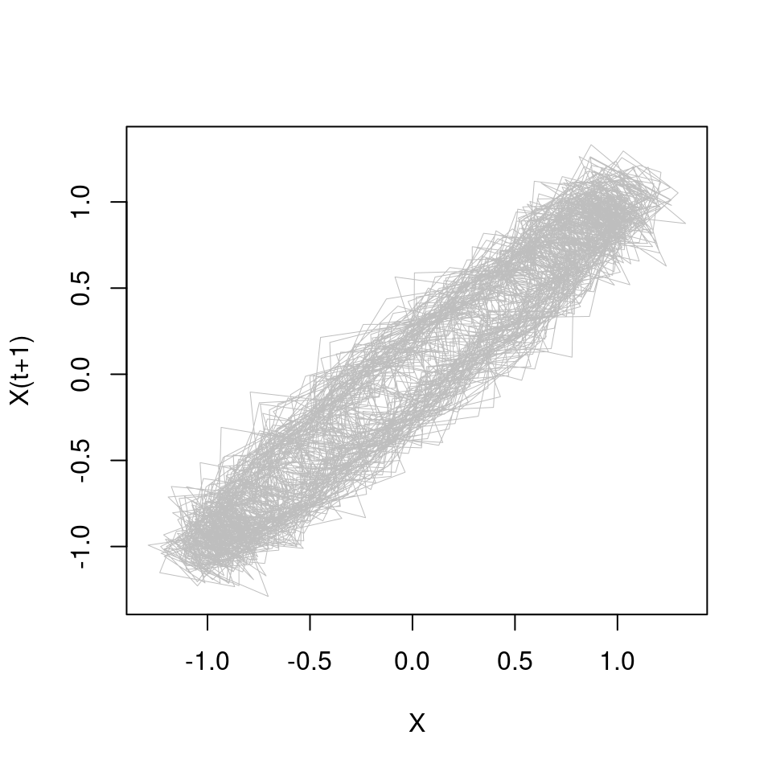

```r
x3 <- x1 + rnorm(n = length(x1), mean = 0, sd = sd(x1)/6)
df3 <- make_block(data.frame(x=x3), max_lag = 5)
plot(x_1 ~ x, data=df3, type="l", col="grey", lwd=0.5,
     ylab = "X(t+1)", xlab = "X" )
```

The atractor reconstruction looks worse now, but we can overcome this problem by replacing the lagged series by another with an increrased lag and see how the reconstructed atractor changes:

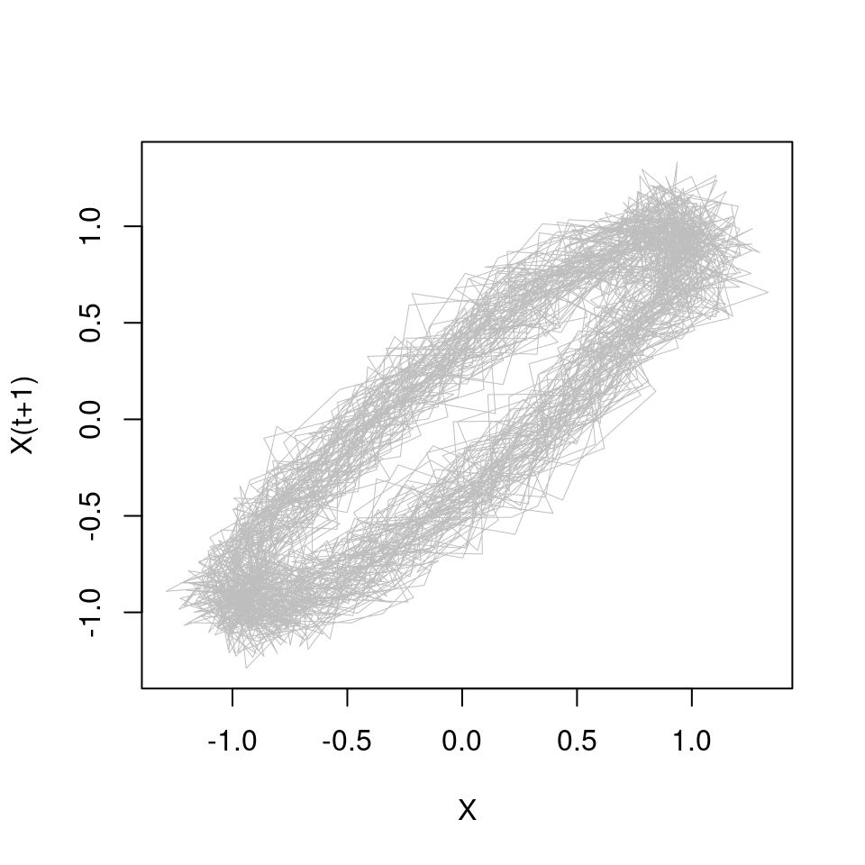

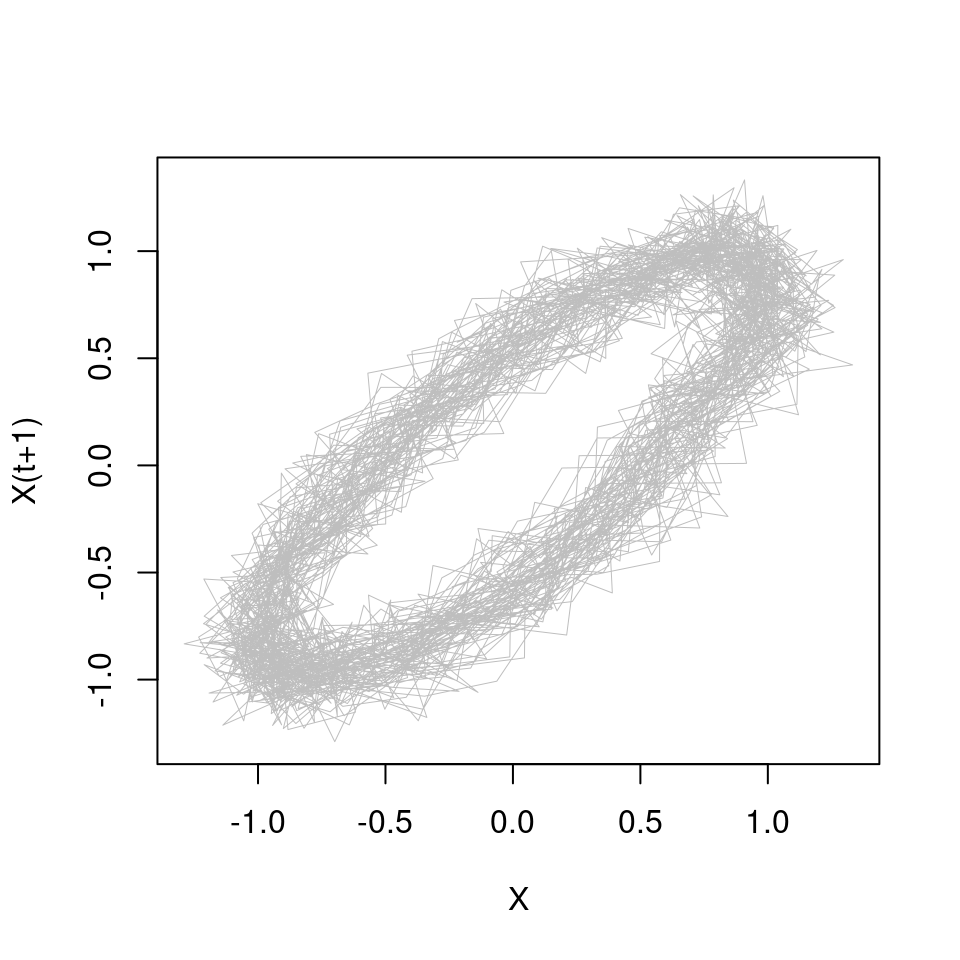

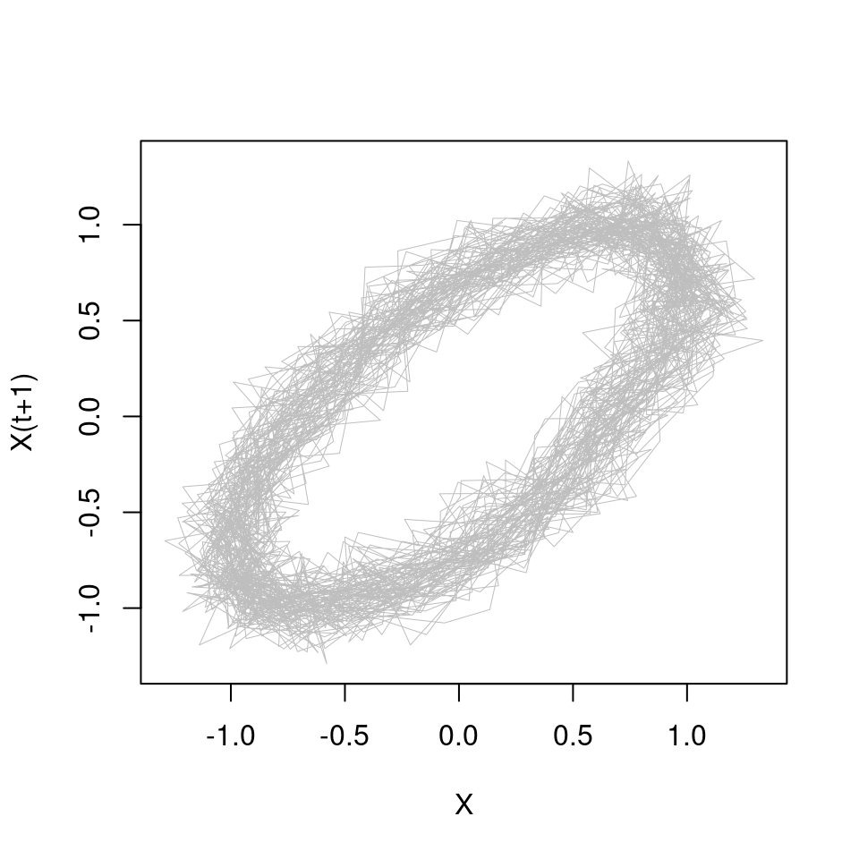

```r
## Checking increasing lags (note that tau=0.2)
plot(x ~ x_2, data=df3, type="l", col="grey", lwd=0.5,
     ylab = "X(t+1)", xlab = "X")
plot(x ~ x_3, data=df3, type="l", col="grey", lwd=0.5,
     ylab = "X(t+1)", xlab = "X")
plot(x ~ x_4, data=df3, type="l", col="grey", lwd=0.5,
     ylab = "X(t+1)", xlab = "X")
```

Another way to overcome the problem with noisy data is to to add more dimensions to the shadow manyfold. We do this adding more axes, that correspond to the time series lagged by the further time steps ($t + \tau, \ t + 2\tau, \ t + 3\tau$…). Even the if the original manifold has a lower dimension its is valid to reconstruct the state space with more dimensions[^1]:

You can check with the interactive plot below how an additional dimension unfolds a bit more the reconstructed atractor. In the following days we will learn some methods to find the optimal dimensions of the manyfold. By now the take-home message is: the more complex the atractor is, the more dimensions you will need to have a good reconstruction.

[interactive chart not shown]

# Problems

## What is the effect of $\tau$ ?

The commands below simulate a new time series of the bimensional harmonic oscilator without measurement error but with a much smaller interval between observations ($\tau=0.01$ time units).

```r
## Generate the data at 0.01 time intervals
time4<-seq(0, 500, by = 0.01)
x4<-sin(time4)
y4<-cos(time4)
```

This change in $\tau$ affects the shape of the reconstruction:

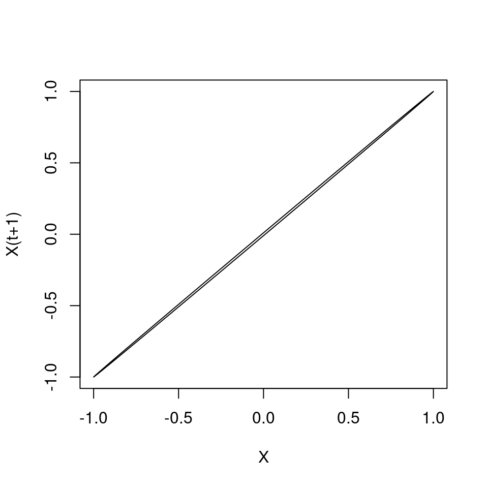

```r
df4 <- make_block(data.frame(x=x4), t=time4)
plot(x_1 ~ x, data=df4, type="l",
     xlab = "X", ylab = "X(t+1)" )
```

How do you explain that? Which practical issues does this fact bring and how to solve them?

### Hints

#### 1

The command above adds a line $x(t) = x(t+1)$ to the manyfold, which can help you to understand the problem with small values of $\tau$:

```r
abline(0,1, col="red")
```

#### 2

Check this site: http://www.physics.emory.edu/faculty/weeks//research/tseries4.html

## Atractor reconstruction

# Learn more

- Sugihara, G., May, R., Ye, H., Hsieh, C.H., Deyle, E., Fogarty, M. and Munch, S., 2012. Detecting causality in complex ecosystems. science, 338(6106), pp.496-500.
- DeAngelis, D.L. and Yurek, S., 2015. Equation-free modeling unravels the behavior of complex ecological systems. Proceedings of the National Academy of Sciences, 112(13), pp.3856-3857.
- [Taken’s Theorem](https://www.youtube.com/watch?v=QQwtrWBwxQg&list=PL-SSmlAMhY3bnogGTe2tf7hpWpl508pZZ&index=2), a video by Sugihara’s Lab.
- Takens, Floris. “Detecting strange attractors in turbulence.” Lecture notes in mathematics 898.1 (1981): 366-381.
- Deyle, E.R. and Sugihara, G., 2011. Generalized theorems for nonlinear state space reconstruction. PLoS One, 6(3), p.e18295.
- Sauer, T., Yorke, J.A. and Casdagli, M., 1991. Embedology. Journal of statistical Physics, 65(3), pp.579-616.

[^1] Sauer, Tim, James A. Yorke, and Martin Casdagli. “Embedology.” Journal of statistical Physics 65.3 (1991): 579-616.